# PG-3 Test Buritos Review Data

Rishabh

November 16, 2018

1. Create a variable called ritos and store your data in it.

```r
ritos <- read.csv("Burritos_Data.csv")
```

2. Print the first 6 rows of ritos

```r
ritos[1:6,]
```

```
##                 Location     Burrito      Date Neighborhood
## 1   graciela's taco shop    adobada  2/14/2016  chula vista
## 2   graciela's taco shop    barbacoa 2/14/2016  chula vista
## 3    cortez mexican food california  10/7/2016      bonsall
## 4 el pueblo mexican food  california 8/10/2016     cardiff
## 5           pollos maria  california 1/27/2016     carlsbad
## 6         senor grubby's  california 4/24/2016     carlsbad
##                   Address Yelp Google Chips Cost Hunger Length Circum
## 1        5047 Central Ave  4.0    4.5    No 5.99      3     NA     NA
## 2        5047 Central Ave  4.0    4.5    No 5.99      2     NA     NA
## 3         5517 Mission Rd  4.2    4.0    No 6.25      4   22.5   18.0
## 4       820 Birmingham Dr  4.0    4.7    No 4.99      4   19.0   21.0
## 5         3055 Harding St  4.0    3.8   Yes 6.59      4     NA     NA
## 6 377 Carlsbad Village Dr  4.0    4.1    No 9.00      2   19.0   21.5
##   Volume Tortilla Temp Meat Fillings Meat.filling Uniformity Salsa Synergy
```

[output cut: 48 more lines]

3. Print the dimension of ritos

```r
dim(ritos)
```

```
## [1] 339  63
```

4. Filter the data using variable nonSD == 0, store it in ritos and print the dimension of this dataset

```r
library(dplyr)
ritos <- filter(ritos, NonSD == 0)
dim(ritos)
```

```
## [1] 332  63
```

5. Print the number of unique values for Burito variable

```r
unique(ritos$Burrito)
```

```
##  [1] adobada                        barbacoa
##  [3] california                     california
##  [5] carne asada                    carnitas
##  [7] chicken                        custom
##  [9] al pastor                      shredded beef
## [11] chicken nopalito               deborah's special
## [13] adobada                        california + guac + sour cream
## [15] california surf                chicken shawarma
## [17] fish                           mahi
## [19] philly                         quesa
## [21] quesaburro                     surf & turf
## [23] chicken asada                  cali diablo
## [25] california chipotle            pork california
## [27] chile verde pork               especial
## [29] machaca                        ranchero steak
```

[output cut: 33 more lines]

6. Using the Burito variable, filter data for california and print the number of unique values for the same. Hint : Use grepl to filter ‘california’

```r
a<-filter(ritos, grepl('california', ritos$Burrito))
length(unique(a$Burrito))
```

```
## [1] 21
```

7. Select the variables Location and Yelp and print the first 6 rows

```r
b <- ritos[c(1,6)]
b[1:6,]
```

```
##                 Location Yelp
## 1   graciela's taco shop  4.0
## 2   graciela's taco shop  4.0
## 3    cortez mexican food  4.2
## 4 el pueblo mexican food  4.0
## 5           pollos maria  4.0
## 6         senor grubby's  4.0
```

8. Select columns with Burito ratings i.e. from Tortilla to Wrap and print the first 6 rows

```r
c <- select(ritos, Tortilla:Wrap)
c[1:6,]
```

```
##   Tortilla Temp Meat Fillings Meat.filling Uniformity Salsa Synergy Wrap
## 1      4.0  4.0  3.0      3.5          4.0        4.5   4.0     4.0  4.5
## 2      3.5  4.0  3.5       NA          4.0         NA   4.0     4.0  1.5
## 3      3.5  4.0  2.5      3.0          1.5        2.5   2.5     2.8  5.0
## 4      4.5  4.5  3.5      4.0          4.5        5.0   2.5     4.5  5.0
## 5      4.0  5.0  4.0      3.5          4.5        5.0   2.5     4.5  4.0
## 6      2.0  3.5  3.0      1.5          1.0        1.0   2.5     1.5  3.5
```

9. Create a new data frame df from ritos, select only columns ‘Taste’, ‘Rec’, ‘Cost’, ’Volume

```r
df <- select(ritos,Taste,Rec,Cost,Volume)
```

10. Create a new column(‘Cost_vol’) in the same dataframe df using the formula(Cost/Volume), print the first 6 rows of the df

```r
Cost_vol <- ritos$Cost/ritos$Volume
d <- cbind(Cost_vol,df)
d[1:6,]
```

```
##    Cost_vol Taste  Rec Cost Volume
## 1        NA   4.0 <NA> 5.99     NA
## 2        NA   4.0 <NA> 5.99     NA
## 3 10.775862   3.2   no 6.25   0.58
## 4  7.447761   4.3  yes 4.99   0.67
## 5        NA   4.2 <NA> 6.59     NA
## 6 12.857143   1.5   no 9.00   0.70
```

11. Plot(dotplot) Taste on y axis and Cost_vol on x axis for df and colour code by variable Rec

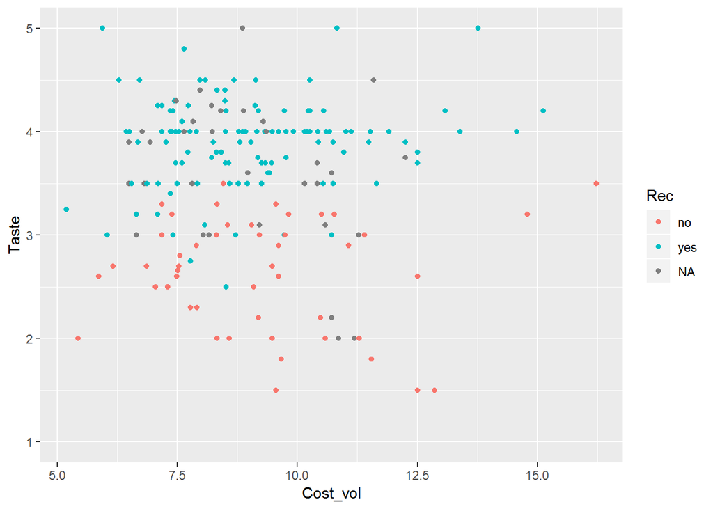

```r
library(ggplot2)
ggplot(df, aes(x = Cost_vol, y = Taste))+
  geom_point(aes(colour = Rec))
```

12. Select burrito rating variable and recommendation(select variable rec and Tortilla to Taste), store this in a new variable called ing and print the first 6 rows

```r
library(data.table)
ing <- select(ritos,c(Rec,Tortilla:Taste))
head(ing)
```

```
##    Rec Tortilla Temp Meat Fillings Meat.filling Uniformity Salsa Synergy
## 1 <NA>      4.0  4.0  3.0      3.5          4.0        4.5   4.0     4.0
## 2 <NA>      3.5  4.0  3.5       NA          4.0         NA   4.0     4.0
## 3   no      3.5  4.0  2.5      3.0          1.5        2.5   2.5     2.8
## 4  yes      4.5  4.5  3.5      4.0          4.5        5.0   2.5     4.5
## 5 <NA>      4.0  5.0  4.0      3.5          4.5        5.0   2.5     4.5
## 6   no      2.0  3.5  3.0      1.5          1.0        1.0   2.5     1.5
##   Wrap Taste
## 1  4.5   4.0
## 2  1.5   4.0
## 3  5.0   3.2
## 4  5.0   4.3
## 5  4.0   4.2
## 6  3.5   1.5
```

13. Convert the above data to long format and store in variable df.melt; use ‘Rec’ and ‘Taste’ as your id variables, print the structure of this dataset

```r
library(UsingR)
library(reshape2)
df.melt<-melt(ing, id.vars=c('Rec','Taste'))
str(df.melt)
```

```
## 'data.frame':    2988 obs. of  4 variables:
##  $ Rec     : Factor w/ 2 levels "no","yes": NA NA 1 2 NA 1 NA 1 2 NA ...
##  $ Taste   : num  4 4 3.2 4.3 4.2 1.5 3 3.5 2.75 3.2 ...
##  $ variable: Factor w/ 9 levels "Tortilla","Temp",..: 1 1 1 1 1 1 1 1 1 1 ...
##  $ value   : num  4 3.5 3.5 4.5 4 2 2.5 3.5 2.5 3 ...
```

14. Plot(ggplot and geom_point) the above dataset using x variable ‘Taste’ and y variable ‘Value’

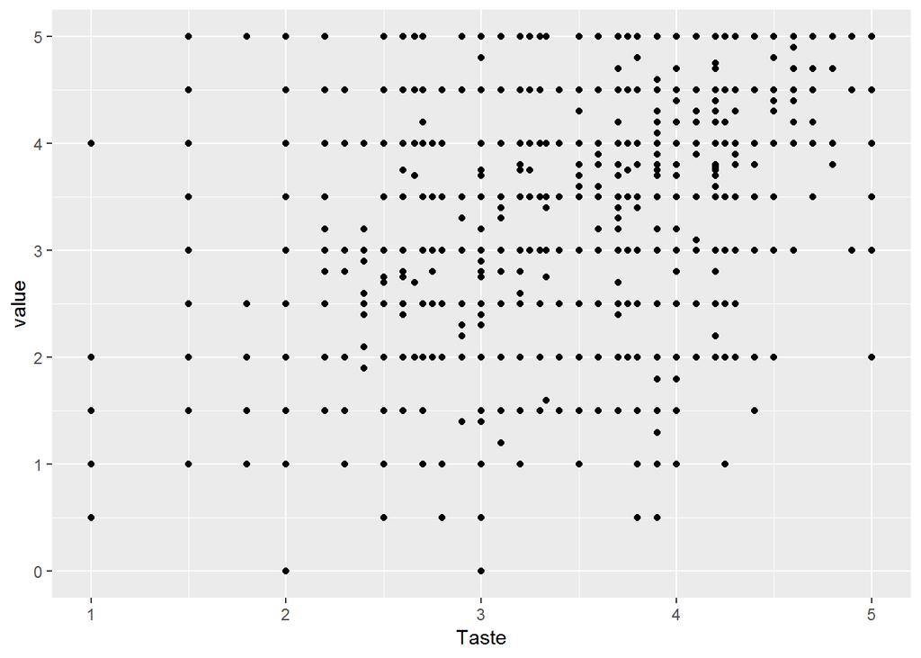

```r
ggplot(df.melt, aes(x = Taste, y = value)) + geom_point()
```

15. Create a facet_wrap of df.melt use x-axis=“Taste”, y-axis=“Value” and colour = “variable”, use geom_point, add a smoother(lm) using geom_smooth, colour the smoother in “black”, give the x axis label as ‘Burrito Qulaity’ and y-axis label as ‘score’

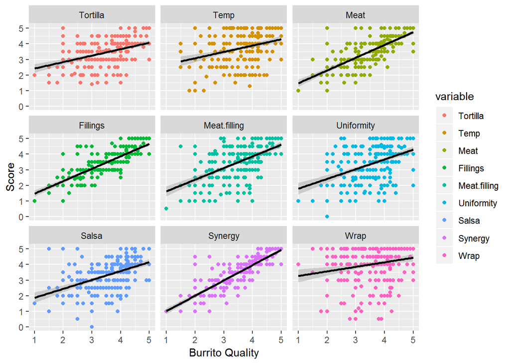

```r
ggplot(df.melt, aes(x = Taste, y = value, colour = variable)) +
  geom_point() + geom_smooth(method='lm', color='black') + facet_wrap(~variable) +
  labs(x='Burrito Quality', y='Score')
```